# Take-home Exercise 1

Pareto chart and Population Pyramid

He Qiyun https://example.com/norajones (SMU MITB (AI))https://scis.smu.edu.sg/  
2022-01-28

# 1. Introduction

Tableau and R are both great tool for visualization. Below shows a Pareto chart for the ‘Superstore-2021’ data and Population Pyramid for ‘respopagesextod2021’ data, made using Tableau.

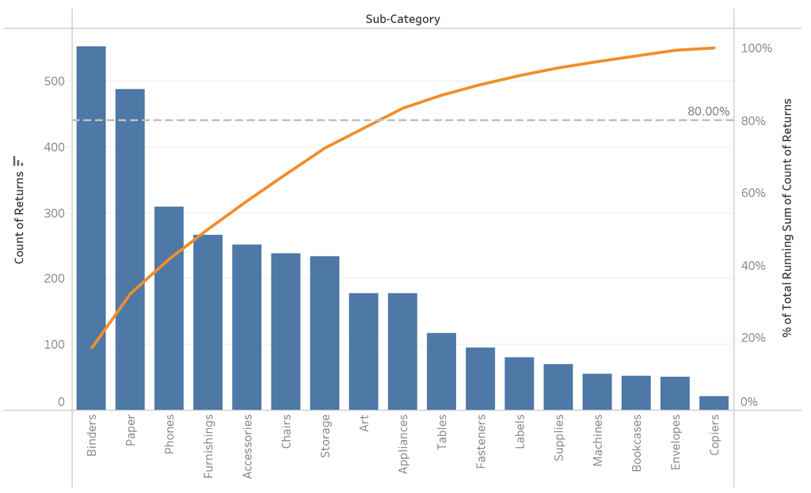

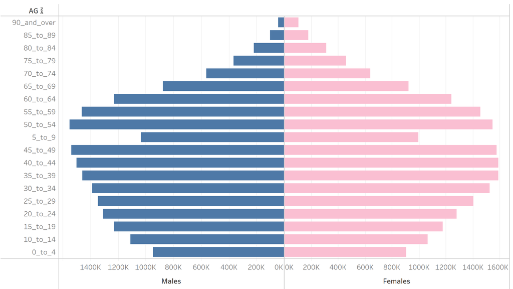

This exercise aims to produce similar graphs using R.

## 1.1 Installing and Launching R Packages

The list of packages required for this exercise are: **tidyverse**, **readxl** , **dplyr** and **ggplot2** Below code chunk installs the required packages and loads them onto RStudio environment.

```r
packages = c('tidyverse','readxl','dplyr','ggplot2')
for(p in packages){
 if(!require(p, character.only = T)){
  install.packages(p)
 }
 library(p,character.only = T)
 }
```

## 1.2 Sketch of Proposed Design

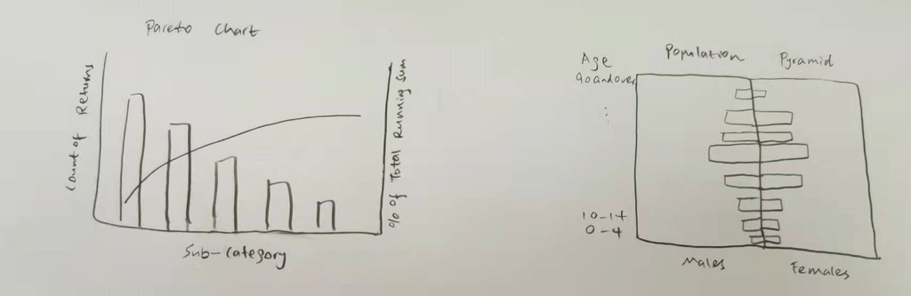

Pareto Chart

# 2.Data preparation and plotting for the first dataset: ‘Superstore-2021.xls’

## 2.1 Import the data

The data is imported with sheet “Orders” and “Returns” stored in different variables. The two tables are joined using left_join function of **dpylr** package based on “Order ID”.

```r
orders <- read_xls("data/Superstore-2021.xls", sheet = "Orders")
returns <- read_xls("data/Superstore-2021.xls", sheet = "Returns")

joined_tab <- left_join(returns, orders, by = c('Order ID'='Order ID'))
joined_tab
```

```
# A tibble: 3,226 x 22
   Returned `Order ID`     `Row ID` `Order Date`
   <chr>    <chr>             <dbl> <dttm>
 1 Yes      CA-2018-100762     6315 2018-11-24 00:00:00
 2 Yes      CA-2018-100762     6316 2018-11-24 00:00:00
 3 Yes      CA-2018-100762     6317 2018-11-24 00:00:00
 4 Yes      CA-2018-100762     6318 2018-11-24 00:00:00
 5 Yes      CA-2018-100762     6315 2018-11-24 00:00:00
 6 Yes      CA-2018-100762     6316 2018-11-24 00:00:00
 7 Yes      CA-2018-100762     6317 2018-11-24 00:00:00
 8 Yes      CA-2018-100762     6318 2018-11-24 00:00:00
 9 Yes      CA-2018-100762     6315 2018-11-24 00:00:00
10 Yes      CA-2018-100762     6316 2018-11-24 00:00:00
# ... with 3,216 more rows, and 18 more variables: Ship Date <dttm>,
#   Ship Mode <chr>, Customer ID <chr>, Customer Name <chr>,
#   Segment <chr>, Country/Region <chr>, City <chr>, State <chr>,
#   Postal Code <dbl>, Region <chr>, Product ID <chr>,
#   Category <chr>, Sub-Category <chr>, Product Name <chr>,
#   Sales <dbl>, Quantity <dbl>, Discount <dbl>, Profit <dbl>
```

## 2.2. Data Preprocessing

To proceed, the number of distinct value in the ‘Returned’ and ‘Sub-Category’ columns are checked using the function unique(). The output shows no null value or other weird values.

```r
unique(joined_tab$'Sub-Category')
```

```
 [1] "Art"         "Labels"      "Paper"       "Phones"
 [5] "Furnishings" "Binders"     "Storage"     "Chairs"
 [9] "Tables"      "Supplies"    "Machines"    "Bookcases"
[13] "Envelopes"   "Appliances"  "Fasteners"   "Accessories"
[17] "Copiers"
```

```r
unique(joined_tab$Returned)
```

```
[1] "Yes"
```

The code chunk below change char values of “Returned” to integer number 1 or 0, as well as changing the name of the “Sub-Category” column to “SubCategory”.

```r
joined_tab$Returned<-ifelse(joined_tab$Returned=="Yes",1,0)

joined_tab <- joined_tab %>%
  rename('SubCategory'='Sub-Category')
colnames(joined_tab)
```

```
 [1] "Returned"       "Order ID"       "Row ID"
 [4] "Order Date"     "Ship Date"      "Ship Mode"
 [7] "Customer ID"    "Customer Name"  "Segment"
[10] "Country/Region" "City"           "State"
[13] "Postal Code"    "Region"         "Product ID"
[16] "Category"       "SubCategory"    "Product Name"
[19] "Sales"          "Quantity"       "Discount"
[22] "Profit"
```

From the output below, we can see that “Returned” is numeric and name of “Sub-Category” is successfully changed.

```r
str(joined_tab)
```

```
tibble [3,226 x 22] (S3: tbl_df/tbl/data.frame)
 $ Returned      : num [1:3226] 1 1 1 1 1 1 1 1 1 1 ...
 $ Order ID      : chr [1:3226] "CA-2018-100762" "CA-2018-100762" "CA-2018-100762" "CA-2018-100762" ...
 $ Row ID        : num [1:3226] 6315 6316 6317 6318 6315 ...
 $ Order Date    : POSIXct[1:3226], format: "2018-11-24" ...
 $ Ship Date     : POSIXct[1:3226], format: "2018-11-29" ...
 $ Ship Mode     : chr [1:3226] "Standard Class" "Standard Class" "Standard Class" "Standard Class" ...
 $ Customer ID   : chr [1:3226] "NG-18355" "NG-18355" "NG-18355" "NG-18355" ...
 $ Customer Name : chr [1:3226] "Nat Gilpin" "Nat Gilpin" "Nat Gilpin" "Nat Gilpin" ...
 $ Segment       : chr [1:3226] "Corporate" "Corporate" "Corporate" "Corporate" ...
 $ Country/Region: chr [1:3226] "United States" "United States" "United States" "United States" ...
 $ City          : chr [1:3226] "Jackson" "Jackson" "Jackson" "Jackson" ...
 $ State         : chr [1:3226] "Michigan" "Michigan" "Michigan" "Michigan" ...
 $ Postal Code   : num [1:3226] 49201 49201 49201 49201 49201 ...
 $ Region        : chr [1:3226] "Central" "Central" "Central" "Central" ...
 $ Product ID    : chr [1:3226] "OFF-AR-10000380" "OFF-LA-10003930" "OFF-PA-10001815" "OFF-PA-10004082" ...
 $ Category      : chr [1:3226] "Office Supplies" "Office Supplies" "Office Supplies" "Office Supplies" ...
 $ SubCategory   : chr [1:3226] "Art" "Labels" "Paper" "Paper" ...
 $ Product Name  : chr [1:3226] "Hunt PowerHouse Electric Pencil Sharpener, Blue" "Dot Matrix Printer Tape Reel Labels, White, 5000/Box" "Xerox 1885" "Adams Telephone Message Book w/Frequently-Called Numbers Space, 400 Messages per Book" ...
 $ Sales         : num [1:3226] 152 197 144 16 152 ...
 $ Quantity      : num [1:3226] 4 2 3 2 4 2 3 2 4 2 ...
 $ Discount      : num [1:3226] 0 0 0 0 0 0 0 0 0 0 ...
 $ Profit        : num [1:3226] 45.58 96.34 69.18 7.98 45.58 ...
```

To further process the data, group_by() function is used to create a new column “Count_of_Returns” that contains the total count of returns for each sub-category. As what we are interested is in the cumulative values, cumsum() function is used to create another column “cumulative” that stores the precentage of the cumulative sum.

```r
#count the returns for each category
SubCategory_grouped <- joined_tab %>% group_by(SubCategory) %>%
                        summarise(Count_of_Returns = sum(Returned),
                        .groups = 'drop')
#order the data
ordered_data <- SubCategory_grouped[order(SubCategory_grouped$Count_of_Returns, decreasing=TRUE),]

#add the cumulative column
ordered_data$cumulative <- cumsum(ordered_data$Count_of_Returns)/sum(ordered_data$Count_of_Returns) * 100

view(ordered_data)
```

## 2.3. Plot the Pareto Chart

Ggplot2 is used to plot the Pareto Chart. geom_bar(), geom_path() and geom_point() are used to plot the data on the chart.

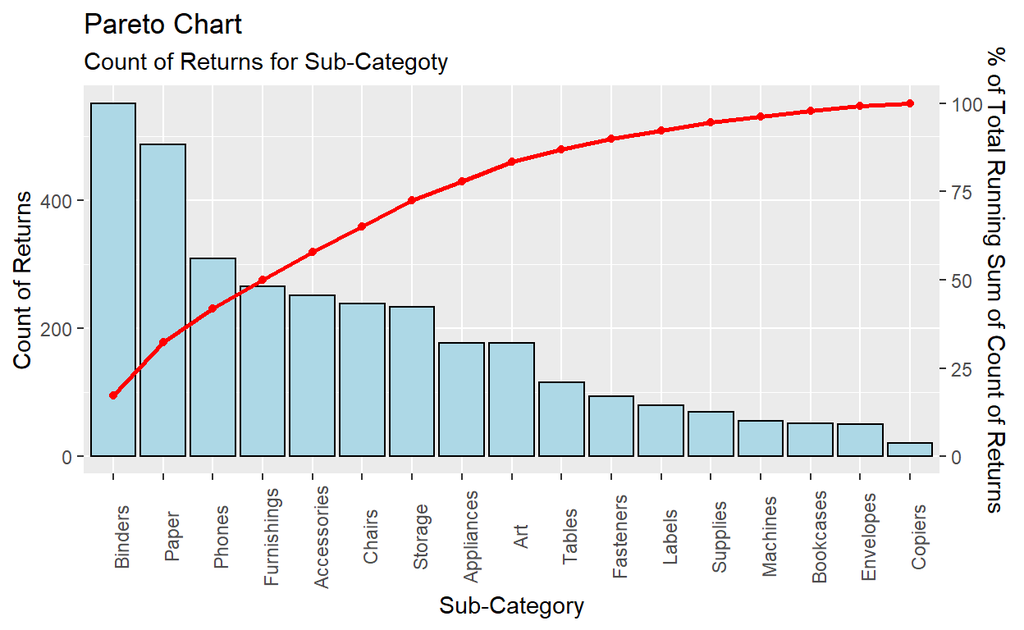

```r
#plot the ggplot
scale <- tail(ordered_data$cumulative, n=1)/head(ordered_data$Count_of_Returns, n=1)

ordered_data$SubCategory = with(ordered_data, reorder(SubCategory, -Count_of_Returns))

ggplot(ordered_data , aes(x= SubCategory)) +

  geom_bar( aes(y=Count_of_Returns), stat="identity", color="black", fill =
               'light blue') +
  geom_path(aes(y=cumulative/scale, group=1),colour="red", size=0.9) +
  geom_point(aes(y=cumulative/scale, group=1),colour="red") +

  scale_y_continuous(
    # Features of the first y-axis
    name = "Count of Returns",
    # Add second y-axis and specify its features
    sec.axis = sec_axis(~ .*scale, name="% of Total Running Sum of Count of Returns")
  ) +
  theme(axis.text.x = element_text(angle = 90)) +
  labs(title="Pareto Chart", subtitle="Count of Returns for Sub-Categoty",
       x="Sub-Category", y=expression(Count_of_Returns(~mu~Ah/~mu~s)))
```

## 2.4: challenges

The main challenges encountered during the process is to identify appropriate functions to use for data preprocessing and plotting. Reading through R documentations and online examples help in the process.

# 3.Data preparation and plotting for the second dataset: ‘respopagesextod2021.csv’

## 3.1 Import the data

```r
data <- read.csv("data/respopagesextod2021.csv")
```

## 3.2 Plot the Population Pyramid

From the summary, the maximum and minimum population value by age group can be observed for both gender. This information is used to specify the scale of the y-axis in the population pyramid

```r
data$pop_males <- ifelse(data$Sex == "Males", data$Pop, 0)
data$pop_females <- ifelse(data$Sex == "Females", data$Pop, 0)

data_grouped <- data %>%
  group_by(AG) %>%
  summarise('Pop_by_AG_Males' = sum(pop_males),
            'Pop_by_AG_Females' = sum(pop_females)) %>%
  ungroup()

summary(data_grouped)
```

```
      AG            Pop_by_AG_Males  Pop_by_AG_Females
 Length:19          Min.   :  6490   Min.   : 15470
 Class :character   1st Qu.: 89035   1st Qu.: 91495
 Mode  :character   Median :115950   Median :115730
                    Mean   :103002   Mean   :107274
                    3rd Qu.:139985   3rd Qu.:147890
                    Max.   :148920   Max.   :155790
```

The population pyramid is plotted using ggplot2.

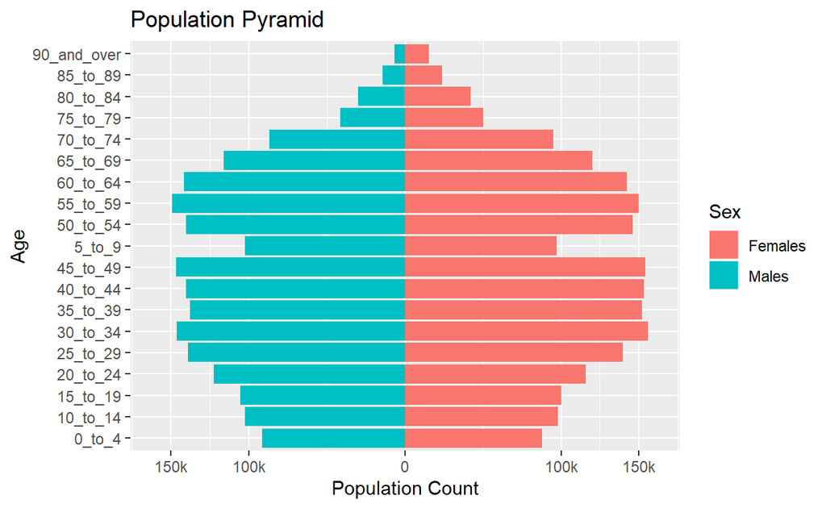

```r
ggplot(data, aes(x = AG, fill = Sex,
                 y = ifelse(test = Sex == "Males", yes = -Pop, no = Pop)))+
  geom_col() +
  scale_y_continuous(breaks = c(-150000,-100000,0,100000,150000), labels = function(br) ifelse(abs(br)>=1000,paste0(abs(br)/1000, "k"),                                                   abs(br)), limits =c(-160000,160000)) +
  labs(title = "Population Pyramid", x = "Age", y = "Population Count") +
  coord_flip()
```

## 3.4: challenges

The main challenge is to adjust the label for the population as the values shown for “MALES” are negative at first. The changes are made by adding conditions for the argument ‘label’ such that absolute values are taken.